# lab5

lab 5

In this project we are going to look at an inclusive search for the standard model Higgs boson in pp collisions at √ s = 13 TeV at the LHC using simulated data [A. Schuy]. The Higgs bosons are produced with large transverse momentum (pT) and decaying to a bottom quark-antiquark pair. The Higgs candidates could be reconstructed as large-radius jets using Calorimeters. Due to large QCD backgorund containmination, the direct 5-sigma observation of this Higgs channel is not accomplished yet[Phys. Rev. Lett. 120, 071802 (2018)]. We are going to use a set of training datasets to optimize event selections in order to enhance the discovery sensitivity. The optimal event selections will be applied to a selected pseudo-experiment data.

Both of you will use the same training samples for analysis. Each sample contains 14 features: ‘pt', 'eta', 'phi', 'mass', 'ee2', 'ee3', 'd2', 'angularity', 't1', 't2', 't3', 't21', 't32', 'KtDeltaR' [Eur. Phys. J. C 79 (2019) 836]. You can explore different strategies for event selection optimization using training samples. The optimal event selection will be applied to pseudo-experiment data.

LHC Introduction

The Large Hadron Collider (LHC) is the world’s largest and most powerful particle accelerator. It first started up on 10 September 2008, and remains the latest addition to CERN’s accelerator complex. The LHC consists of a 27-kilometre ring of superconducting magnets with a number of accelerating structures to boost the energy of the particles along the way.

pt----Transverse Momentum $\sqrt{p^2_x + p^2_y}$

eta Pseudorapidity----$-ln[\tan(\frac{\theta}{2})]$

phi Azimuthal Angle $cos^-1(x/r)$

mass Invariant Mass $E^2 = P^2 + m^2$

ee2 2-point ECF ratio

ee3 3-point ECF ratio

d2 3-to-2 point ECF ratio $E_{CF3}*(\frac{E_{CF1}}{E_{CF2}})^3$

angularity Angularity

t1-3 N-Subjettiness $\tau_N = \frac{1}{d_0}\sum_{k=1}^M(p_{T,k}\times \Delta R_{min,k})$

t21 2-to-1-Subjettiness $t2/t1$

t32 3-to-2-Subjettiness $t3/t2$

KtDeltaR Cluster sequence $\Delta R=\sqrt{\Delta\eta^2+\Delta\varphi^2}$

```python
import h5py
import statistics
import math
import scipy.signal
import pickle
import numpy as np
import pandas as pd
import matplotlib
import matplotlib.pyplot as plt
import scipy
from scipy import stats
import seaborn as sns
infile = open ("higgs_100000_pt_250_500.pkl",'rb')
higgs = pickle.load(infile)
infile2 = open ("qcd_100000_pt_250_500.pkl",'rb')
qcd = pickle.load(infile2)

print("Higgs Signal categories: ", higgs.keys())
print("QCD background categories: ", qcd.keys())
```

```
Higgs Signal categories:  Index(['pt', 'eta', 'phi', 'mass', 'ee2', 'ee3', 'd2', 'angularity', 't1',
       't2', 't3', 't21', 't32', 'KtDeltaR'],
      dtype='object')
QCD background categories:  Index(['pt', 'eta', 'phi', 'mass', 'ee2', 'ee3', 'd2', 'angularity', 't1',
       't2', 't3', 't21', 't32', 'KtDeltaR'],
      dtype='object')
```

```python
# Print two variables, mass and d2, of the first 10 jets
for i in range(10):
 print(higgs['mass'][i],higgs['d2'][i])
```

```
125.15036485403486 1.2980200835589373
130.55267214662751 1.445626317832899
125.70306309880351 0.986596849742669
126.21585336608149 1.2184665392866647
132.18250371689544 1.2917844364435773
125.67653506886116 0.4343656746345235
127.65400794990293 0.9312049446719695
124.16656852260293 0.9493560863407668
122.13035265114684 3.0022665455324082
125.19144633816678 0.5539996032675585
```

2.Explore the data

pt

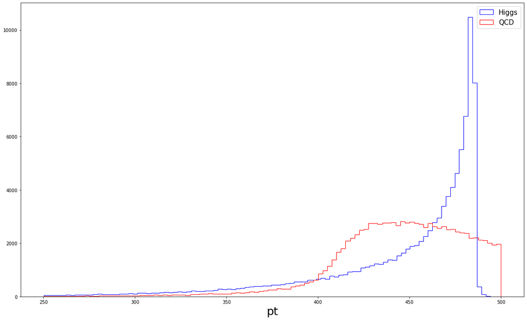

```python
h = higgs['pt']
q= qcd['pt']
fig,ax = plt.subplots(figsize=(20,12))
ax.hist(h,100,color='b',histtype='step',label="Higgs")
ax.hist(q,100,color='r',histtype='step',label="QCD")
ax.set_xlabel("pt",fontsize=25)
ax.legend(fontsize=15);
```

Both Higgs and QCD are not good in small value. Higgs spikes around 480, QCD mainly spread between 420--500.

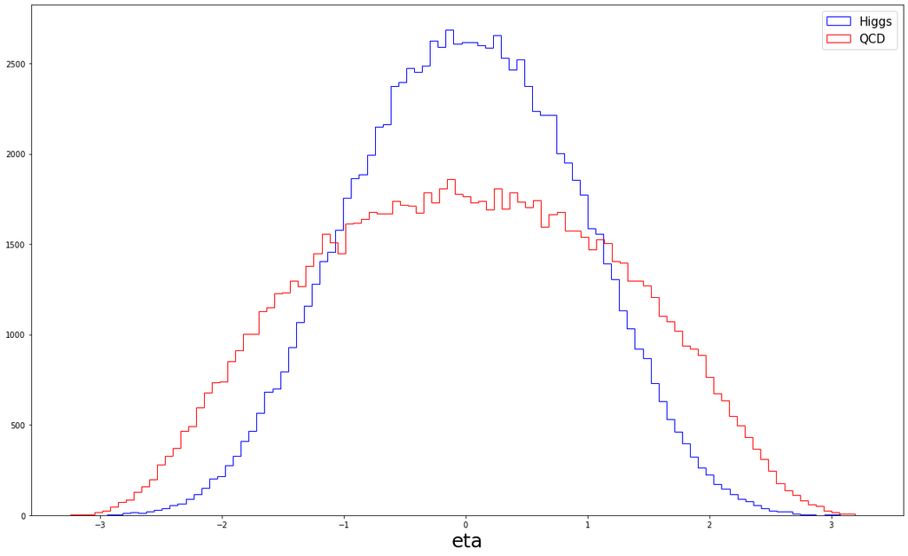

```python
h = higgs['eta']
q = qcd['eta']
fig,ax = plt.subplots(figsize=(20,12))
ax.hist(h,100,color='b',histtype='step',label="Higgs")
ax.hist(q,100,color='r',histtype='step',label="QCD")
ax.set_xlabel("eta",fontsize=25)
ax.legend(fontsize=15);
```

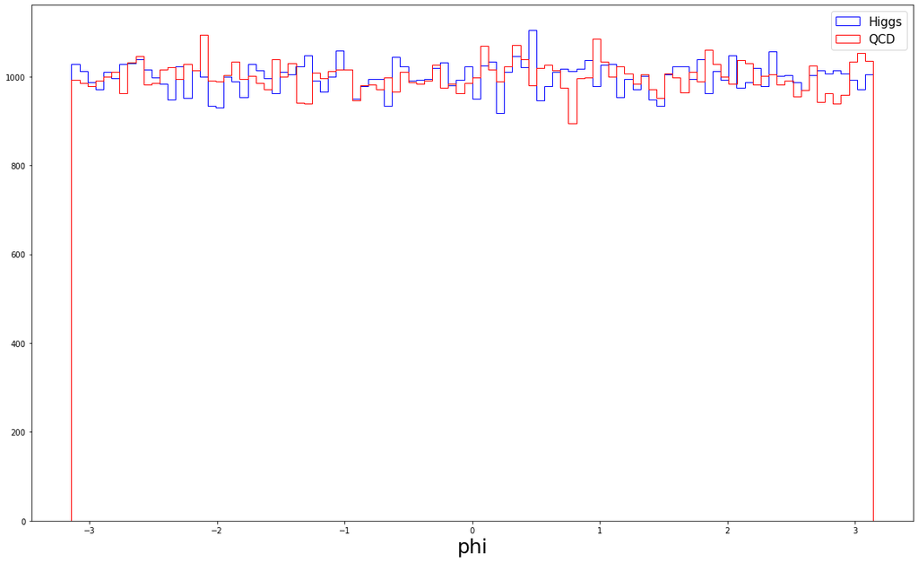

```python
h = higgs['phi']
q = qcd['phi']
fig,ax = plt.subplots(figsize=(20,12))
ax.hist(h,100,color='b',histtype='step',label="Higgs")
ax.hist(q,100,color='r',histtype='step',label="QCD")
ax.set_xlabel("phi",fontsize=25)
ax.legend(fontsize=15);
```

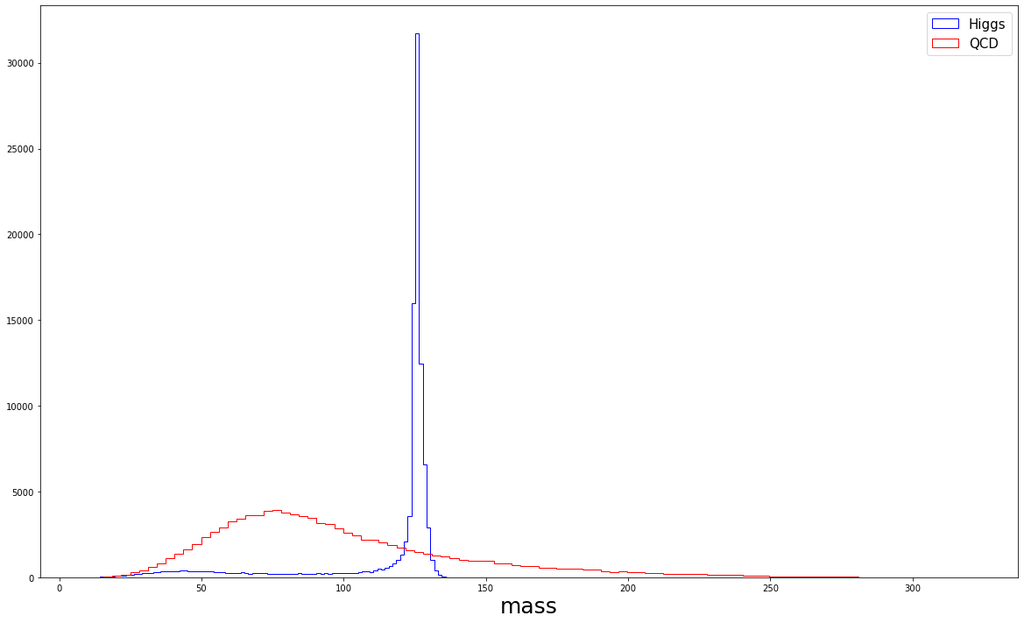

```python
h = higgs['mass']
q = qcd['mass']
fig,ax = plt.subplots(figsize=(20,12))
ax.hist(h,100,color='b',histtype='step',label="Higgs")
ax.hist(q,100,color='r',histtype='step',label="QCD")
ax.set_xlabel("mass",fontsize=25)
ax.legend(fontsize=15);
```

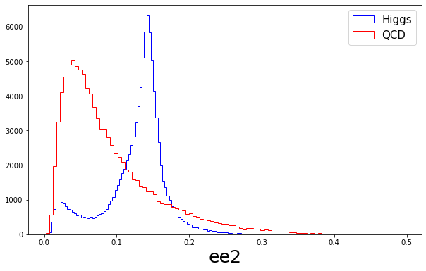

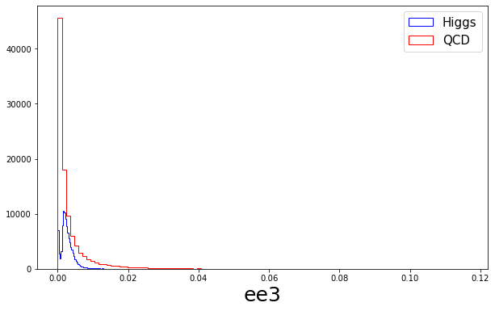

```python
h = higgs['ee2']
q = qcd['ee2']
fig,ax = plt.subplots(figsize=(10,6))
ax.hist(h,100,color='b',histtype='step',label="Higgs")
ax.hist(q,100,color='r',histtype='step',label="QCD")
ax.set_xlabel("ee2",fontsize=25)
ax.legend(fontsize=15);
h = higgs['ee3']
q = qcd['ee3']
fig,ax = plt.subplots(figsize=(10,6))
ax.hist(h,100,color='b',histtype='step',label="Higgs")
ax.hist(q,100,color='r',histtype='step',label="QCD")
ax.set_xlabel("ee3",fontsize=25)
ax.legend(fontsize=15);
```

There's a huge difference between e2 and e3 with Higgs. In e3, both Higgs and QCD spike at 0. Higgs shrinks in e3.

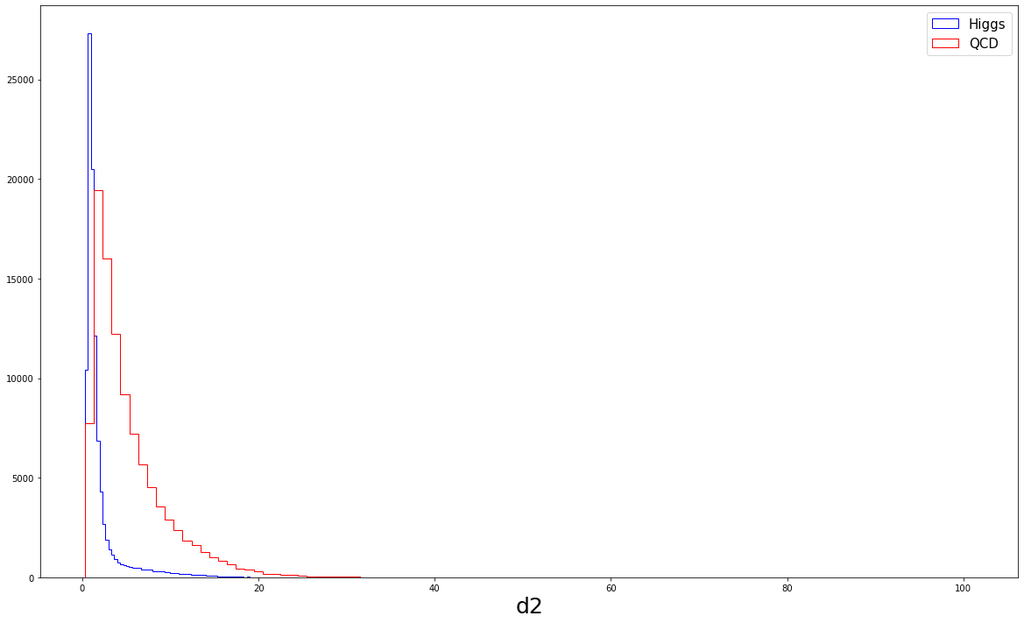

```python
h = higgs['d2']
q = qcd['d2']
fig,ax = plt.subplots(figsize=(20,12))
ax.hist(h,100,color='b',histtype='step',label="Higgs")
ax.hist(q,100,color='r',histtype='step',label="QCD")
ax.set_xlabel("d2",fontsize=25)
ax.legend(fontsize=15);
```

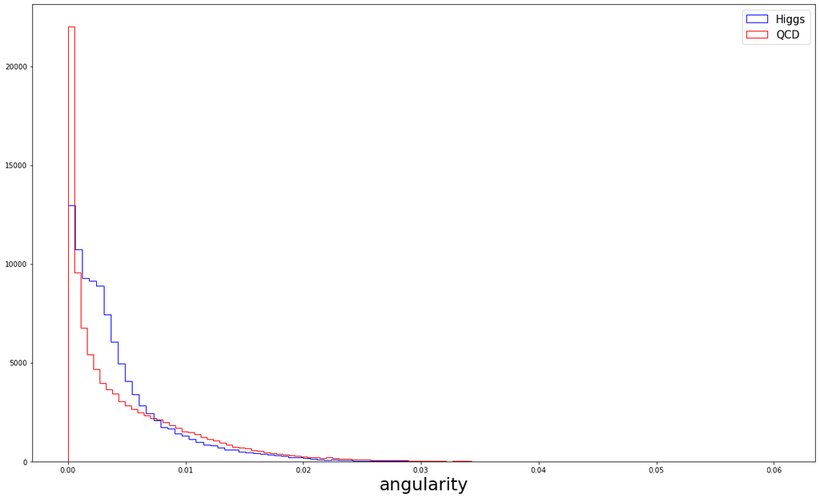

```python
h = higgs['angularity']
q = qcd['angularity']
fig,ax = plt.subplots(figsize=(20,12))
ax.hist(h,100,color='b',histtype='step',label="Higgs")
ax.hist(q,100,color='r',histtype='step',label="QCD")
ax.set_xlabel("angularity",fontsize=25)
ax.legend(fontsize=15);
```

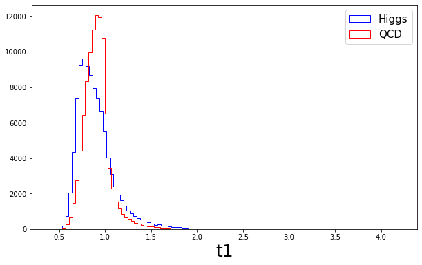

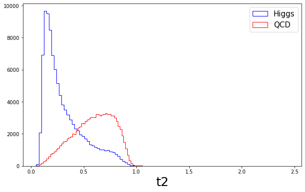

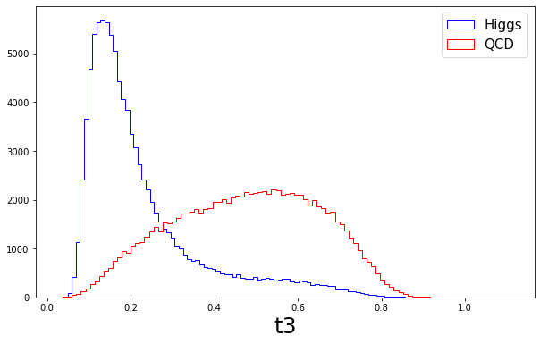

```python
h = higgs['t1']
q = qcd['t1']
fig,ax = plt.subplots(figsize=(10,6))
ax.hist(h,100,color='b',histtype='step',label="Higgs")
ax.hist(q,100,color='r',histtype='step',label="QCD")
ax.set_xlabel("t1",fontsize=25)
ax.legend(fontsize=15);
h = higgs['t2']
q = qcd['t2']
fig,ax = plt.subplots(figsize=(10,6))
ax.hist(h,100,color='b',histtype='step',label="Higgs")
ax.hist(q,100,color='r',histtype='step',label="QCD")
ax.set_xlabel("t2",fontsize=25)
ax.legend(fontsize=15);
h = higgs['t3']
q = qcd['t3']
fig,ax = plt.subplots(figsize=(10,6))
ax.hist(h,100,color='b',histtype='step',label="Higgs")
ax.hist(q,100,color='r',histtype='step',label="QCD")
ax.set_xlabel("t3",fontsize=25)
ax.legend(fontsize=15);
```

We can see the QCD's peak shift to the left from t1 to t3. t2 and t3 are pretty much the same, but a big difference with t1. t1's range is 0.5 to 2.0. t2 and t3 range is 0 to 1.

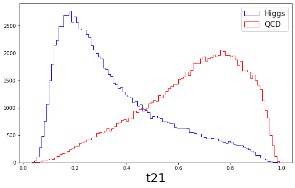

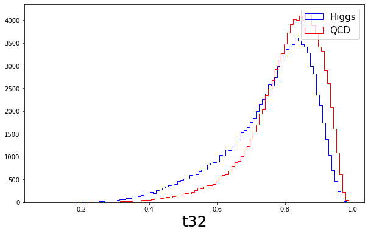

```python
h = higgs['t21']
q = qcd['t21']
fig,ax = plt.subplots(figsize=(10,6))
ax.hist(h,100,color='b',histtype='step',label="Higgs")
ax.hist(q,100,color='r',histtype='step',label="QCD")
ax.set_xlabel("t21",fontsize=25)
ax.legend(fontsize=15);
h = higgs['t32']
q = qcd['t32']
fig,ax = plt.subplots(figsize=(10,6))
ax.hist(h,100,color='b',histtype='step',label="Higgs")
ax.hist(q,100,color='r',histtype='step',label="QCD")
ax.set_xlabel("t32",fontsize=25)
ax.legend(fontsize=15);
```

For t21, they look like symmetric to each other. Higgs decreases from the left peak. And QCD increases to the right peak.

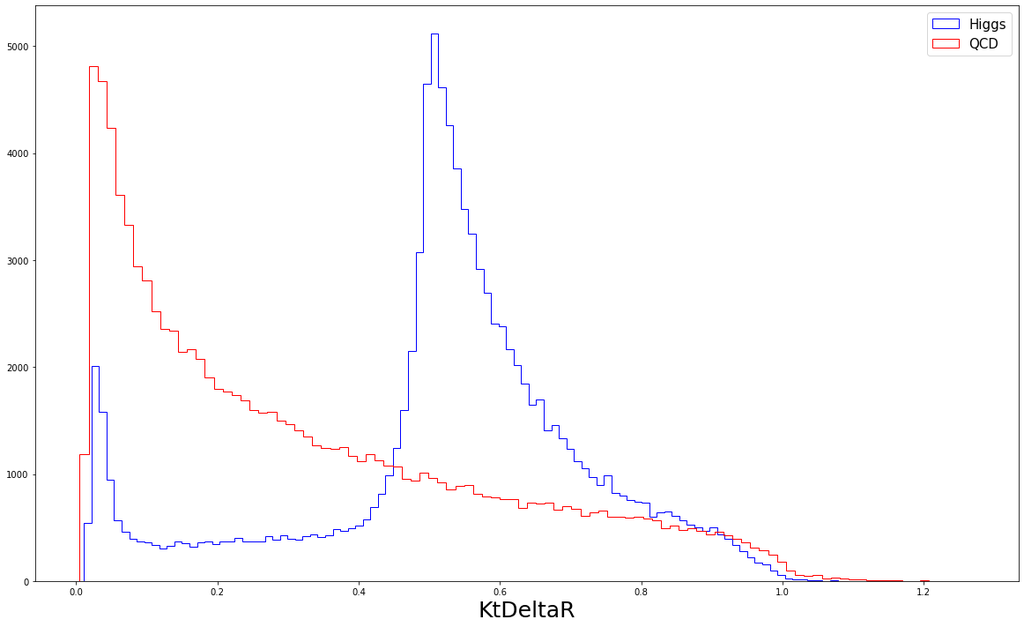

```python
h = higgs['KtDeltaR']
q = qcd['KtDeltaR']
fig,ax = plt.subplots(figsize=(20,12))
ax.hist(h,100,color='b',histtype='step',label="Higgs")
ax.hist(q,100,color='r',histtype='step',label="QCD")
ax.set_xlabel("KtDeltaR",fontsize=25)
ax.legend(fontsize=15);
```

Correlations of features

```python
higgscor = pd.read_pickle("higgs_100000_pt_250_500.pkl")
qcdcor = pd.read_pickle("qcd_100000_pt_250_500.pkl")
```

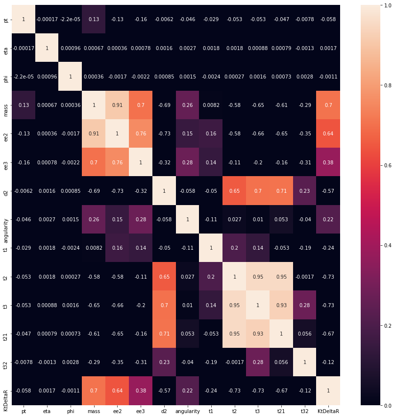

```python
corr = pd.concat([higgscor,qcdcor],axis=0).corr()
sns.heatmap(corr, square = False, annot = True, vmin=0, vmax=1)
```

From the heatmap we can see mass, ee2 and ee3 have big correlation. t2, t3 and t21 have big correlation.